# cov stats

| X1 | X2 | X3 |
| --- | --- | --- |
| ptg000037l | 1 | 6379 |
| ptg000037l | 2 | 902 |
| ptg000037l | 3 | 163 |
| ptg000037l | 4 | 447 |
| ptg000037l | 5 | 619 |
| ptg000037l | 6 | 820 |

| X1 | X2 | X3 |
| --- | --- | --- |
| ptg000037l | 1 | 6379 |
| ptg000037l | 2 | 902 |
| ptg000037l | 3 | 163 |
| ptg000037l | 4 | 447 |
| ptg000037l | 5 | 619 |
| ptg000037l | 6 | 820 |

| nb_same | n |
| --- | --- |
| TRUE | 254877 |

> gencov is congruent, so this is not the issue. Then, the problem arises with where I set my cutoffs. I don’t have that information handy here.

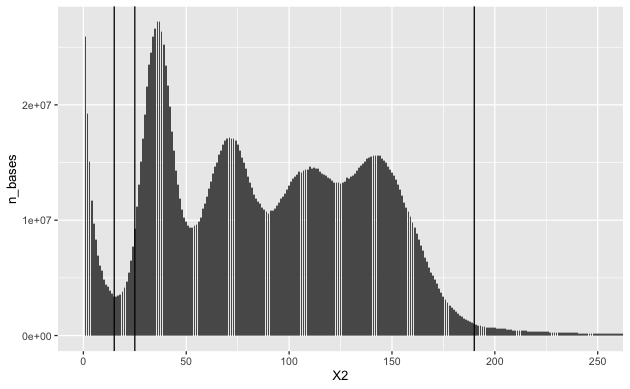

```
old_stats_file <- "~/Desktop/Comai_Lab/github-repositories/layer/analysis/purge_haplotigs/coverage_stats.csv"
old_stats_header <- system(paste0("grep '^#' ", old_stats_file), intern = T) %>%
  str_remove("^#") %>%
  str_split(pattern = ",") %>%
  pluck(1)
old_stats <- read_csv(old_stats_file,
                      col_names = old_stats_header,
                      comment = "#")
```

```
head(old_stats)
```

| contig | contig_reassign | bases_hap_dip | bases_low_high | bases_all | perc_low_coverage | perc_hap_coverage | perc_dip_coverage | perc_high_coverage |
| --- | --- | --- | --- | --- | --- | --- | --- | --- |
| ptg000001l | NA | 6357708 | 91059 | 6448767 | 0.000 | 2.443 | 96.145 | 1.412 |
| ptg000002l | s | 15863550 | 75790 | 15939340 | 0.348 | 92.143 | 7.382 | 0.127 |
| ptg000003l | s | 28592070 | 265988 | 28858058 | 0.331 | 56.830 | 42.248 | 0.591 |
| ptg000004l | s | 25907166 | 486454 | 26393620 | 0.113 | 47.891 | 50.266 | 1.730 |
| ptg000005l | NA | 49967567 | 1230683 | 51198250 | 0.078 | 2.128 | 95.468 | 2.326 |
| ptg000006l | NA | 40707901 | 414509 | 41122410 | 0.060 | 4.134 | 94.858 | 0.948 |

```
new_stats_file <- "~/Desktop/Comai_Lab/github-repositories/layer/analysis/purge_haplotigs/2025_coverage_stats.csv"
new_stats_header <- system(paste0("grep '^#' ", new_stats_file), intern = T) %>%
  str_remove("^#") %>%
  str_split(pattern = ",") %>%
  pluck(1)
new_stats <- read_csv(new_stats_file,
                      col_names = new_stats_header,
                      comment = "#")
```

```
head(new_stats)
```

| contig | contig_reassign | bases_hap_dip | bases_low_high | bases_all | perc_low_coverage | perc_hap_coverage | perc_dip_coverage | perc_high_coverage |
| --- | --- | --- | --- | --- | --- | --- | --- | --- |
| ptg000001l | NA | 6354760 | 94007 | 6448767 | 0.000 | 2.214 | 96.329 | 1.458 |
| ptg000002l | s | 15872092 | 67249 | 15939341 | 0.264 | 93.239 | 6.339 | 0.158 |
| ptg000003l | s | 28572709 | 308946 | 28881655 | 0.355 | 56.041 | 42.889 | 0.715 |
| ptg000004l | s | 25954407 | 446860 | 26401267 | 0.054 | 47.301 | 51.006 | 1.639 |
| ptg000005l | NA | 49809944 | 1388306 | 51198250 | 0.070 | 1.888 | 95.401 | 2.642 |
| ptg000006l | NA | 40662059 | 460351 | 41122410 | 0.042 | 3.081 | 95.800 | 1.078 |

> These numbers are slightly different and I don’t know why

```
nrow(old_stats)
```

```
[1] 2427
```

```
nrow(new_stats)
```

```
[1] 2467
```

> Neither the fai file of the old or new coverage stats matches the contig number of the .fai file for the initial assembly. This is so weird. More trouble. FAI has 2,474 contigs in it. This is what I used for the mapping and mutation calling for the paper. What did I use for the purge long read mapping? Also has 2,474 contigs in it. /scratch/kramundson/RP_hifiasm/data/reads/RP_tetra_homcov140_l3/RP_tetra_homcov140.p_ctg.fa has 2,474 contigs in it. Check the bam header of the long read alignments - should have 2,474 contigs in it. It does. If so, this means the table that was used to generate the coverage_stats.csv used for purging was of a different assembly. Could be that the gencov file was from an outdated genome? It wasn’t.

[output not shown]

[output not shown]

```
  select(contig, bases_all) %>%
  dplyr::rename(contig_old = contig,
                bases_all_old = bases_all) %>%
  full_join(.,
            new_stats %>% select(contig, bases_all)) %>%
  dplyr::rename(contig_new = contig,
                bases_all_new = bases_all) %>%
  View
```

```
Error in View : `by` must be supplied when `x` and `y` have no common variables.
```

> Coverage stats files seem to be from different assembly versions. Slightly different numbers of contigs too. Trouble.

```
# this means I can't reproduce the coverage stats file or the assembly with the data I currently have
```